# Homework 4

Yu-Jen Lin

#### b04b01036@ntu.edu.tw

#### ——————————————————————————————————————————————————–

#### Set working directory

```r
setwd("~/R")
```

#### Read enviANDdensity.csv into R

```r
enviANDdensity <- read.csv(file="~/R/enviANDdensity.csv", header=TRUE)
```

Because we only need the data in “FishDensity..ind..1000m3.” and “CopepodDensity.ind..m3.”, I take these two columns out and set as “FishDensity” and “CopepodDensity” separately.

```r
FishDensity <- enviANDdensity$FishDensity..ind..1000m3.
CopepodDensity <- enviANDdensity$CopepodDensity.ind..m3.
```

#### Re-do HW3 [Normal theory] mean and SE(mean)

```r
FishDensity.mean <- mean(FishDensity)
FishDensity.mean
```

```
## [1] 322.4516
```

```r
FishDensity.SE <- var(FishDensity)^0.5/length(FishDensity)^0.5
FishDensity.SE
```

```
## [1] 61.23107
```

```r
CopepodDensity.mean <- mean(CopepodDensity)
CopepodDensity.mean
```

```
## [1] 1972.374
```

```r
CopepodDensity.SE <- var(CopepodDensity)^0.5/length(CopepodDensity)^0.5
CopepodDensity.SE
```

```
## [1] 342.5549
```

###### ————————————————————————————————————————————————————————————————————————————-

#### 1. Compute the mean and stand error of the mean for the fish and copepod density (all data points) respectively using Jackknife. Plot the histogram of Jackknife means.

#### [Jackknife] mean and stand error of the mean

1. FishDensity

```r
FishDensity.Jackknife.means <- c() # set a vector to put the following sampling results

for (i in 1:length(FishDensity)) {
FishDensity.Jackknife.i <- FishDensity[-i] # single sampling result
FishDensity.Jackknife.means[i] <- mean(FishDensity.Jackknife.i) # put every mean of every single result into the vector I've created
}

FishDensity.Jackknife.means.mean <- mean(FishDensity.Jackknife.means) # mean of Jackknife means
FishDensity.Jackknife.means.mean
```

```
## [1] 322.4516
```

```r
FishDensity.Jackknife.means.SE <- var(FishDensity.Jackknife.means)^0.5

# calculate SE
sum.F = 0
for (i in 1:length(FishDensity)) {
  sum.F.i <- (FishDensity.Jackknife.means[i] - FishDensity.Jackknife.means.mean)^2
  sum.F <- sum.F + sum.F.i
}
FishDensity.Jackknife.means.SE <-(sum.F*(34-1)/34) ^ 0.5
FishDensity.Jackknife.means.SE
```

```
## [1] 61.23107
```

2. CopepodDensity

```r
CopepodDensity.Jackknife.means <- c() # set a vector to put the following sampling results

for (i in 1:length(CopepodDensity)) {
CopepodDensity.Jackknife.i <- CopepodDensity[-i] # single sampling result
CopepodDensity.Jackknife.means[i] <- mean(CopepodDensity.Jackknife.i) # put every mean of every single result into the vector I've created
}

CopepodDensity.Jackknife.means.mean <- mean(CopepodDensity.Jackknife.means) # mean of Jackknife means
CopepodDensity.Jackknife.means.mean
```

```
## [1] 1972.374
```

```r
# calculate SE
sum.C = 0
for (i in 1:length(CopepodDensity)) {
  sum.C.i <- (CopepodDensity.Jackknife.means[i] - CopepodDensity.Jackknife.means.mean)^2
  sum.C <- sum.C + sum.C.i
}
CopepodDensity.Jackknife.means.SE <-(sum.C*(34-1)/34) ^ 0.5
CopepodDensity.Jackknife.means.SE
```

```
## [1] 342.5549
```

#### plot the Jackknife histogram

1. FishDensity means by Jackknife and Normal Theory

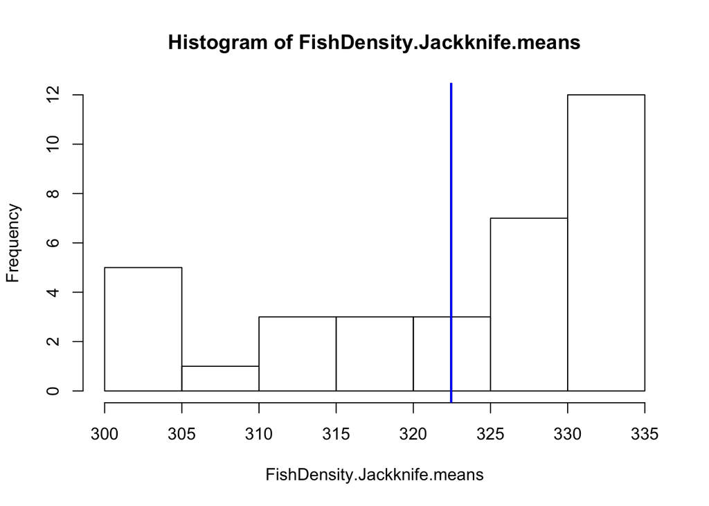

```r
hist(FishDensity.Jackknife.means)
abline(v = FishDensity.mean, col = "black", lwd = 2)
abline(v = FishDensity.Jackknife.means.mean, col = "blue", lwd = 2)
```

2. CopepodDensity means by Jackknife and Normal Theory

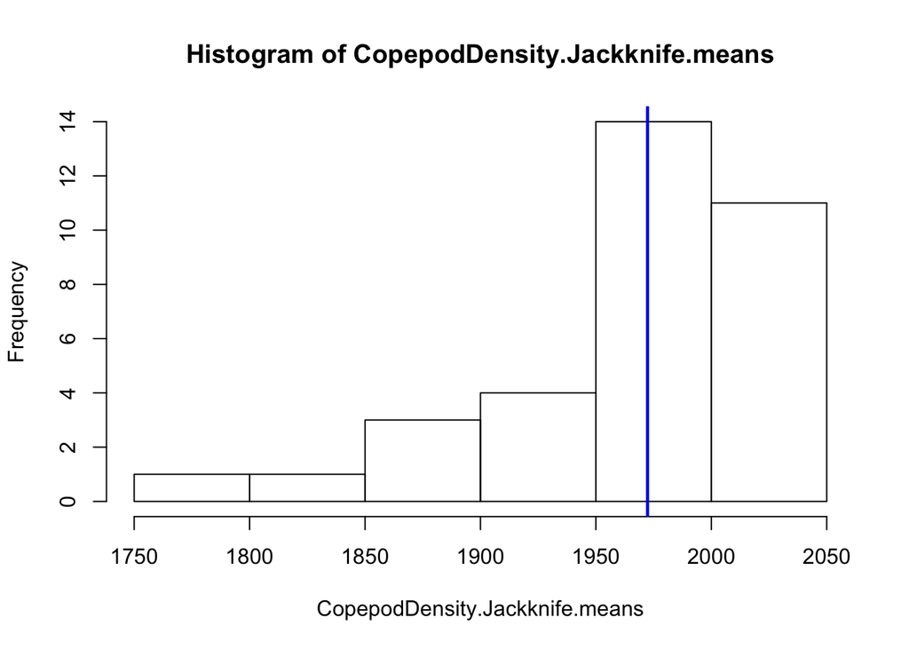

```r
hist(CopepodDensity.Jackknife.means)
abline(v = CopepodDensity.mean, col = "black", lwd = 2)
abline(v = CopepodDensity.Jackknife.means.mean, col = "blue", lwd = 2)
```

###### ————————————————————————————————————————————————————————————————————————————-

#### 2. Compute the regression coefficients for

#### fish = β0+β1*copepod and Jackknife SE of β0 and β1. #### Plot the histogram of Jackknife β0 and β1.

#### Compute the regression coefficients for

#### fish(y) = β0 + β1 * copepod(x).

Dimension of y -> (n,1) Dimension of β0 -> (n,1) Dimension of β1 -> (k+1,1) Dimension of X -> (n,k+1)

```r
n <- length(FishDensity)
k <- 1

y  <- matrix(FishDensity, nrow=n, ncol=1, byrow = TRUE) # put the original sample into y
x  <- matrix(c(rep(1, times=n),CopepodDensity), nrow=n, ncol=k+1, byrow = FALSE)  # put the original sample into x

β1 <- solve(t(x) %*% x) %*% t(x) %*% y
β1
```

```
##            [,1]
## [1,] 93.0646559
## [2,]  0.1162999
```

```r
β0 <- y - x %*% β1  # fish(y) = β0 + β1 * copepod(x)
```

Thus, through β1, I found the intercept of the regression line is 93.0647 and the slope of the regression line is 0.1163. y = 93.0647 + 0.1163*x

#### Plot fish (dependent) v.s. copepod (independent) and the regression line.

I plot the regression line I just computed in below. (blue) y = 93.0647 + 0.1163*x

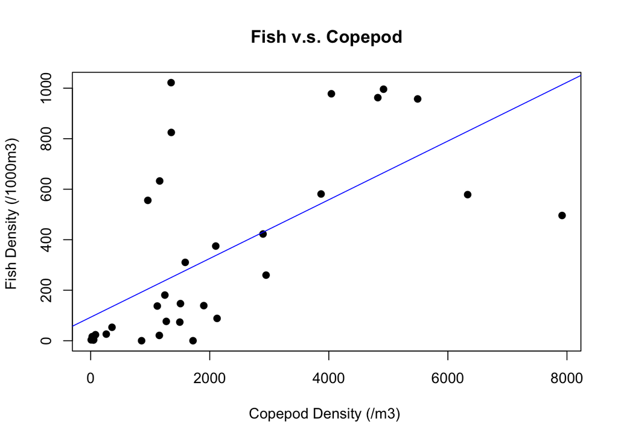

```r
plot(CopepodDensity, FishDensity, main="Fish v.s. Copepod",
    xlab="Copepod Density (/m3) ", ylab="Fish Density (/1000m3) ", pch=19)
abline(a=93.0647, b=0.1163, col="blue") # regression line (y~x) # the regression line I computed in previous step, a=intercept b=slope
```

#### [Jackknife] SE(β0) and SE(β1).

```r
# set vectors to put the following sampling results
Jackknife.β0 <- c()
Jackknife.β1 <- c()

# set starting points
n.jn <- length(FishDensity)-1
k.jn <- length(FishDensity)

# Jackknife
for (i in 1:k.jn) {
Jackknife.Fish.i <- FishDensity[-i] # single sampling result
Jackknife.Copepod.i <- CopepodDensity[-i] # single sampling result

y.jn  <- matrix(Jackknife.Fish.i, nrow=n.jn, ncol=1, byrow = FALSE) # put the Jackknife sample into y.jn
x.jn  <- cbind(c(rep(1, times=n.jn)), as.matrix(Jackknife.Copepod.i)) # combine the new column into the x.jn

β1.jn <- solve(t(x.jn) %*% x.jn) %*% t(x.jn) %*% y.jn
Jackknife.β0[i] <- β1.jn[1] # intercept
Jackknife.β1[i] <- β1.jn[2] # slope
}

Jackknife.β0.mean <- mean(Jackknife.β0)
Jackknife.β0.mean
```

```
## [1] 92.73093
```

```r
Jackknife.β1.mean <- mean(Jackknife.β1)
Jackknife.β1.mean
```

```
## [1] 0.1165492
```

```r
# calculate SE
sum.β0.J = 0
for (i in 1:length(Jackknife.β0)) {
  sum.β0.J.i <- (Jackknife.β0[i] - mean(Jackknife.β0))^2
  sum.β0.J <- sum.β0.J + sum.β0.J.i
}
Jackknife.β0.SE <-(sum.β0.J*(34-1)/34) ^ 0.5
Jackknife.β0.SE
```

```
## [1] 69.27329
```

```r
sum.β1.J = 0
for (i in 1:length(Jackknife.β1)) {
  sum.β1.J.i <- (Jackknife.β1[i] - mean(Jackknife.β1))^2
  sum.β1.J <- sum.β1.J + sum.β1.J.i
}
Jackknife.β1.SE <-(sum.β1.J*(34-1)/34) ^ 0.5
Jackknife.β1.SE
```

```
## [1] 0.0380003
```

#### Plot the histogram of Jackknife β0 and β1.

Jackknife β0 means by Jackknife and Normal Theory

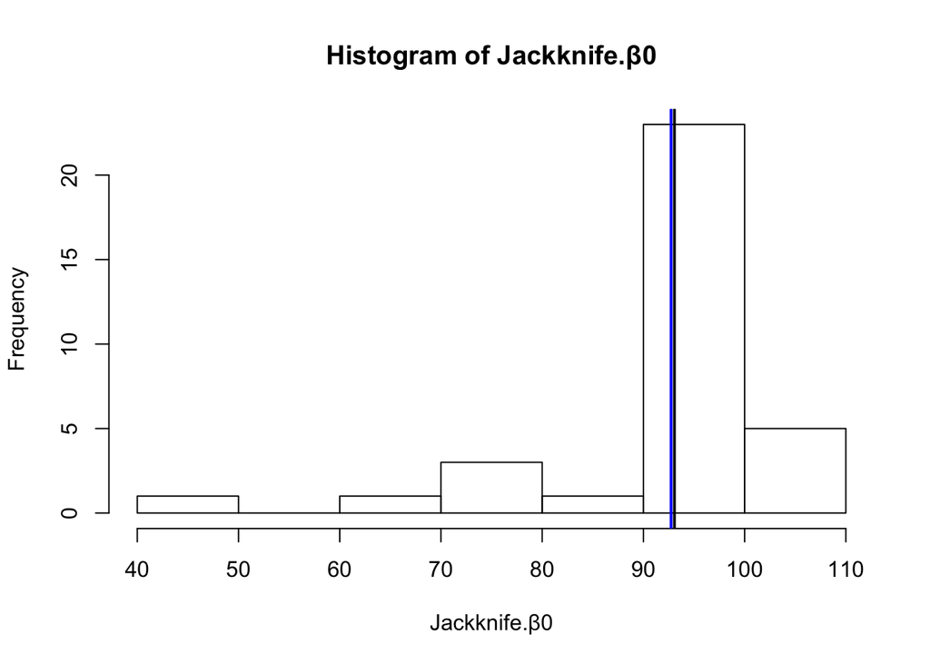

```r
hist(Jackknife.β0)
abline(v = β1[1], col = "black", lwd = 2) # mean calculated by Normal Theory
abline(v = Jackknife.β0.mean, col = "blue", lwd = 2) # mean calculated by Jackknife
```

Jackknife β1 means by Jackknife and Normal Theory

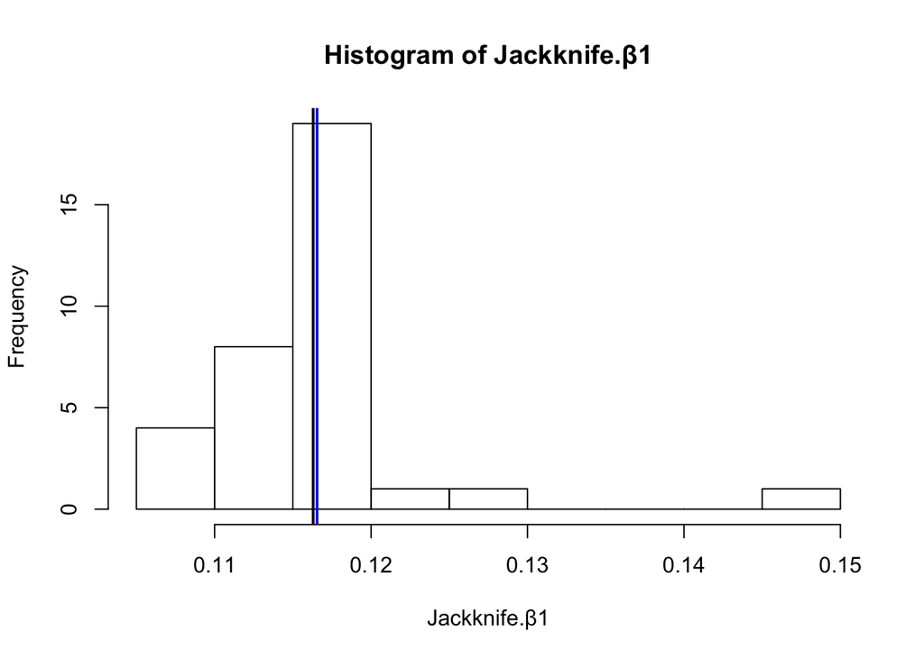

```r
hist(Jackknife.β1)
abline(v = β1[2], col = "black", lwd = 2) # mean calculated by Normal Theory
abline(v = Jackknife.β1.mean, col = "blue", lwd = 2) # mean calculated by Jackknife
```

###### ————————————————————————————————————————————————————————————————————————————-

#### Re-do HW3 [bootstrap] mean and SE(mean)

1. FishDensity bootstrap means

```r
FishDensity.bootstrap.means <- c() # set a vector to put the following sampling results
for (i in 1:999) {
random <- ceiling(runif(34, min=0, max=34))
bootstrap.i <- FishDensity[random] # single sampling result
FishDensity.bootstrap.means[i] <- mean(bootstrap.i) # put every mean of every single result into the vector I've created
}
FishDensity.bootstrap.means <- append(FishDensity.bootstrap.means, FishDensity.mean) # add the mean calculated by normal theory (total:1000)
FishDensity.bootstrap.means.mean <- mean(FishDensity.bootstrap.means) # mean of bootstrap means
FishDensity.bootstrap.means.mean
```

```
## [1] 322.5974
```

```r
FishDensity.bootstrap.means.SE <- var(FishDensity.bootstrap.means)^0.5
FishDensity.bootstrap.means.SE
```

```
## [1] 58.87328
```

2. CopepodDensity bootstrap means

```r
CopepodDensity.bootstrap.means <- c() # set a vector to put the following sampling results
for (i in 1:999) {
random <- ceiling(runif(34, min=0, max=34))
bootstrap.i <- CopepodDensity[random] # single sampling result
CopepodDensity.bootstrap.means[i] <- mean(bootstrap.i) # put every mean of every single result into the vector I've created
}
CopepodDensity.bootstrap.means <- append(CopepodDensity.bootstrap.means, CopepodDensity.mean) # add the mean calculated by normal theory (total:1000)
CopepodDensity.bootstrap.means.mean <- mean(CopepodDensity.bootstrap.means) # mean of bootstrap means
CopepodDensity.bootstrap.means.mean
```

```
## [1] 1995.342
```

```r
CopepodDensity.bootstrap.means.SE <- var(CopepodDensity.bootstrap.means)^0.5
CopepodDensity.bootstrap.means.SE
```

```
## [1] 329.9263
```

###### ————————————————————————————————————————————————————————————————————————————-

#### Re-do HW3 [bootstrap] SE(β0) and SE(β1).

```r
# set vectors to put the following sampling results
bootstrap.β0 <- c()
bootstrap.β1 <- c()

# set starting points
n.bt <- length(FishDensity)
k.bt <- 999

# bootstrap
for (i in 1:k.bt) {
random <- ceiling(runif(34, min=0, max=34))
bootstrap.Fish.i <- FishDensity[random] # single sampling result
bootstrap.Copepod.i <- CopepodDensity[random] # single sampling result

y.bt  <- matrix(bootstrap.Fish.i, nrow=n.bt, ncol=1, byrow = FALSE) # put the bootstrap sample into y.bt
x.bt  <- cbind(c(rep(1, times=n.bt)), as.matrix(bootstrap.Copepod.i)) # combine the new column into the x.bt

β1.bt <- solve(t(x.bt) %*% x.bt) %*% t(x.bt) %*% y.bt
bootstrap.β0[i] <- β1.bt[1] # intercept
bootstrap.β1[i] <- β1.bt[2] # slope
}

bootstrap.β0 <- append(bootstrap.β0, β1.bt[1]) # add the SE(β0) calculated by normal theory (total:1000)
bootstrap.β1 <- append(bootstrap.β1, β1.bt[2]) # add the SE(β1) calculated by normal theory (total:1000)

bootstrap.β0.mean <- mean(bootstrap.β0)
bootstrap.β0.mean
```

```
## [1] 85.80885
```

```r
bootstrap.β1.mean <- mean(bootstrap.β1)
bootstrap.β1.mean
```

```
## [1] 0.1227115
```

```r
bootstrap.β0.SE <- var(bootstrap.β0)^0.5
bootstrap.β0.SE
```

```
## [1] 63.51382
```

```r
bootstrap.β1.SE <- var(bootstrap.β1)^0.5
bootstrap.β1.SE
```

```
## [1] 0.03162558
```

###### ————————————————————————————————————————————————————————————————————————————-

#### 3. Compare the estimates for Q1 and Q2 obtained from normal theory, bootstrap, and jackknife.

```r
Fish.Normal_Theory <- c(FishDensity.mean, FishDensity.SE)
Fish.Bootstrap <- c(FishDensity.bootstrap.means.mean, FishDensity.bootstrap.means.SE)
Fish.Jackknife <- c(FishDensity.Jackknife.means.mean, FishDensity.Jackknife.means.SE)
Fish <- data.frame(Fish.Normal_Theory, Fish.Bootstrap, Fish.Jackknife)
rownames(Fish) <- c("mean", "SE(mean)" )
Fish
```

```
##          Fish.Normal_Theory Fish.Bootstrap Fish.Jackknife
## mean              322.45163      322.59741      322.45163
## SE(mean)           61.23107       58.87328       61.23107
```

```r
Copepod.Normal_Theory <- c(CopepodDensity.mean, CopepodDensity.SE)
Copepod.Bootstrap <- c(CopepodDensity.bootstrap.means.mean, CopepodDensity.bootstrap.means.SE)
Copepod.Jackknife <- c(CopepodDensity.Jackknife.means.mean, CopepodDensity.Jackknife.means.SE)
Copepod <- data.frame(Copepod.Normal_Theory, Copepod.Bootstrap, Copepod.Jackknife)
rownames(Copepod) <- c("mean", "SE(mean)" )
Copepod
```

```
##          Copepod.Normal_Theory Copepod.Bootstrap Copepod.Jackknife
## mean                 1972.3741         1995.3419         1972.3741
## SE(mean)              342.5549          329.9263          342.5549
```

```r
Normal_Theory <- c(β1[1], β1[2])
Bootstrap <- c(bootstrap.β0.mean, bootstrap.β1.mean)
Jackknife <- c(Jackknife.β0.mean, Jackknife.β1.mean)
regression.coefficients <- data.frame(Normal_Theory, Bootstrap, Jackknife)
rownames(regression.coefficients) <- c("SE(β0)", "SE(β1)" )
regression.coefficients
```

[output not shown]